# module_3

### Packaging

When you write several commands in a file to be executed as a program, this file is called a script. When a program is imported, it is called a module.

As a developer starts implementing several modules, they tend to organize them into what is called a package. So, basically, a package is a group of similar modules that usually have a similar purpose.

Fortunatelly, one can use packages already implemented. Commonly, these packages are available in different repositories (https://pypi.org/, https://anaconda.org/anaconda/repo). To install them, we can use pip or conda, the latter only if anaconda or miniconda is installed (https://docs.conda.io/projects/conda/en/latest/user-guide/install/index.html).

##### Installing Packages

```python
!conda install -y -c conda-forge numpy
#or using pip:
#pip install numpy
```

```
Solving environment: ...working... done

# All requested packages already installed.

Solving environment: ...working... done

# All requested packages already installed.
```

```
WARNING conda.gateways.disk.delete:unlink_or_rename_to_trash(143): Could not remove or rename D:\Programas\Miniconda3\pkgs\cache\62c98390.q.  Please remove this file manually (you may need to reboot to free file handles)
```

```python
!conda install -y -c conda-forge pandas
#or using pip:
#pip install pandas
```

```
Solving environment: ...working... done

# All requested packages already installed.
```

```python
!conda install -y -c conda-forge matplotlib
#or using pip:
#pip install matplotlib
```

```
Solving environment: ...working... done

# All requested packages already installed.
```

##### Importing Packages

```python
import pandas
import pandas as pd
import numpy as np
```

```python
print('pandas:', pandas)
print('pd:', pd) # pd is the abbreviation of pandas
```

```
pandas: <module 'pandas' from 'd:\\Programas\\Miniconda3\\lib\\site-packages\\pandas\\__init__.py'>
pd: <module 'pandas' from 'd:\\Programas\\Miniconda3\\lib\\site-packages\\pandas\\__init__.py'>
```

```python
from pandas import read_csv # import read_csv from pandas
from pandas import * #import all
```

```python
print('read csv function:', read_csv)
print('Dataframe:', DataFrame)
```

```
read csv function: <function read_csv at 0x0000024C49364B80>
Dataframe: <class 'pandas.core.frame.DataFrame'>
```

### Pandas

Package for data analysis and manipulation with Python.

A Pandas DataFrame is a 2 dimensional data structure, like a 2 dimensional array, or a table with rows and columns.

To create a pandas dataframe you can simply use the DataFrame function and input data as list of lists, an array or a dictionary.

```python
df = pd.DataFrame(data=np.random.randn(8, 3), columns=["A", "B", "C"])
df
```

|  | A | B | C |
| --- | --- | --- | --- |
| 0 | 0.864530 | -1.003338 | 0.271737 |
| 1 | -1.491983 | 0.138082 | -0.815527 |
| 2 | 0.630004 | -0.293650 | -1.033868 |
| 3 | -0.510186 | -2.261765 | -0.471721 |
| 4 | 1.918651 | 0.331338 | -0.332846 |
| 5 | 0.539755 | 2.063139 | 0.560949 |
| 6 | -0.904045 | 0.764139 | -0.084560 |
| 7 | -0.458361 | -1.640421 | -0.711340 |

```python
df.columns
```

```
Index(['A', 'B', 'C'], dtype='object')
```

##### Reading and Saving Data

You can also read a csv file directly into a dataframe

```python
df = pd.read_csv(filepath_or_buffer="Dataset.csv", sep=';') #filepath_or_buffer is the file name, sep is the separator.
```

```python
print(df.shape) #number of rows and columns, respectively.
print(df.size) #number of elements in the DataFrame.
```

```
(3628, 79)
286612
```

```python
df1 = df[0:20] #first 20 rows
df1.to_csv("small_dataset.csv") #save to csv

df1
```

|  | GENEID | Series1_NHBE_Mock_1 | Series1_NHBE_Mock_2 | Series1_NHBE_Mock_3 | Series1_NHBE_SARS.CoV.2_1 | Series1_NHBE_SARS.CoV.2_2 | Series1_NHBE_SARS.CoV.2_3 | Series2_A549_Mock_1 | Series2_A549_Mock_2 | Series2_A549_Mock_3 | ... | Series15_COVID19Lung_1 | Series16_A549.ACE2_Mock_1 | Series16_A549.ACE2_Mock_2 | Series16_A549.ACE2_Mock_3 | Series16_A549.ACE2_SARS.CoV.2_1 | Series16_A549.ACE2_SARS.CoV.2_2 | Series16_A549.ACE2_SARS.CoV.2_3 | Series16_A549.ACE2_SARS.CoV.2_Rux_1 | Series16_A549.ACE2_SARS.CoV.2_Rux_2 | Series16_A549.ACE2_SARS.CoV.2_Rux_3 |
| --- | --- | --- | --- | --- | --- | --- | --- | --- | --- | --- | --- | --- | --- | --- | --- | --- | --- | --- | --- | --- | --- |
| 0 | ENSG00000000419 | 120.034393 | 131.451753 | 170.452953 | 125.265139 | 132.344820 | 107.620008 | 88.408165 | 89.844217 | 77.637454 | ... | 0.000000 | 145.446032 | 153.835486 | 135.297651 | 423.392810 | 421.474542 | 494.256103 | 438.259709 | 512.558780 | 456.832635 |
| 1 | ENSG00000000938 | NaN | NaN | NaN | NaN | NaN | NaN | NaN | NaN | NaN | ... | NaN | NaN | NaN | NaN | NaN | NaN | NaN | NaN | NaN | NaN |
| 2 | ENSG00000001036 | 50.244314 | 58.172474 | 56.375800 | 43.914287 | 58.292681 | 50.852851 | 67.750967 | 63.191281 | 76.467979 | ... | 7.657940 | 76.925777 | 78.187190 | 68.180600 | 47.155518 | 34.356783 | 27.629114 | 38.079700 | 37.368870 | 43.241076 |
| 3 | ENSG00000001084 | 115.933023 | 130.861693 | 142.053064 | 95.400297 | 102.257721 | 90.218057 | 130.546186 | 123.016111 | 128.915555 | ... | 0.000000 | 135.284281 | 134.173512 | 121.529672 | 60.005965 | 56.960359 | 53.156004 | 67.632764 | 70.026928 | 66.073926 |
| 4 | ENSG00000001630 | 123.512402 | 136.290390 | 145.305417 | 121.426738 | 140.753268 | 134.511727 | 146.768611 | 142.990583 | 133.884305 | ... | 52.354346 | 66.988022 | 86.182422 | 75.708361 | 52.236693 | 53.011013 | 42.890689 | 67.408437 | 51.954017 | 68.662528 |
| 5 | ENSG00000002549 | 56.388879 | 51.197459 | 47.990623 | 59.589814 | 66.010817 | 63.754341 | 42.811556 | 45.991682 | 49.933490 | ... | 26.091697 | 37.012072 | 37.730146 | 34.684987 | 231.832891 | 199.032186 | 131.130268 | 27.029787 | 21.969127 | 24.721793 |
| 6 | ENSG00000002587 | 2.126043 | 3.036326 | 3.458344 | 2.741030 | 2.745598 | 2.522046 | 1.040513 | 0.642342 | 1.062697 | ... | 0.000000 | 0.631133 | 0.267944 | 0.421174 | 0.421679 | 0.961703 | 0.775012 | 0.648633 | 0.585769 | 1.567742 |
| 7 | ENSG00000002726 | NaN | NaN | NaN | NaN | NaN | NaN | NaN | NaN | NaN | ... | NaN | NaN | NaN | NaN | NaN | NaN | NaN | NaN | NaN | NaN |
| 8 | ENSG00000002746 | 0.018725 | 0.000000 | 0.013097 | 0.041112 | 0.021439 | 0.000000 | 2.843613 | 2.713340 | 2.565684 | ... | 0.000000 | 2.772634 | 2.415100 | 2.110377 | 1.357419 | 1.311163 | 1.174038 | 1.692237 | 1.996560 | 1.187457 |
| 9 | ENSG00000003137 | 4.002448 | 5.011934 | 4.264756 | 4.804482 | 3.426286 | 3.930027 | 24.275588 | 25.232773 | 21.958837 | ... | 0.000000 | 6.875780 | 7.622033 | 8.921910 | 35.092360 | 55.150365 | 53.649797 | 26.390029 | 44.870376 | 44.626138 |
| 10 | ENSG00000003987 | 0.000000 | 0.116030 | 0.000000 | 0.000000 | 0.000000 | 0.000000 | 0.512249 | 0.276933 | 0.232660 | ... | 0.000000 | 0.353731 | 0.600699 | 1.044090 | 1.477113 | 1.751767 | 1.628891 | 1.716711 | 1.231147 | 1.922094 |
| 11 | ENSG00000003989 | 0.093439 | 0.417323 | 0.114375 | 0.435951 | 0.267462 | 0.337908 | 3.520938 | 3.525060 | 3.577347 | ... | 4.820743 | 8.468494 | 9.418555 | 8.265679 | 29.784439 | 28.170802 | 26.272248 | 20.770774 | 16.259264 | 19.628496 |
| 12 | ENSG00000004455 | 117.707817 | 97.962858 | 92.264028 | 101.674190 | 112.370882 | 105.016411 | 56.120131 | 54.824949 | 59.119501 | ... | 16.649214 | 71.676512 | 69.778880 | 70.574178 | 82.739537 | 99.803188 | 114.604883 | 79.496738 | 104.780966 | 104.882919 |
| 13 | ENSG00000004468 | NaN | NaN | NaN | NaN | NaN | NaN | NaN | NaN | NaN | ... | NaN | NaN | NaN | NaN | NaN | NaN | NaN | NaN | NaN | NaN |
| 14 | ENSG00000004478 | 95.149362 | 85.438876 | 87.649251 | 90.488365 | 104.523751 | 106.085003 | 131.977224 | 130.942257 | 137.162687 | ... | 78.661373 | 234.764667 | 254.747554 | 259.943387 | 135.113100 | 156.065602 | 148.809699 | 125.429059 | 165.957899 | 169.772920 |
| 15 | ENSG00000004660 | 2.393721 | 1.802541 | 2.219446 | 2.016684 | 1.720919 | 1.589318 | 24.253589 | 25.368173 | 25.275964 | ... | 0.000000 | 8.242912 | 10.498455 | 10.578342 | 32.284342 | 30.751101 | 28.577316 | 54.853499 | 44.682465 | 42.363046 |
| 16 | ENSG00000004779 | 78.787388 | 93.914844 | 94.020166 | 68.083164 | 90.208688 | 79.640154 | 210.588345 | 194.447194 | 192.010629 | ... | 0.000000 | 240.555815 | 236.276202 | 242.434454 | 141.880594 | 136.680388 | 125.167430 | 126.483884 | 129.291992 | 141.367865 |
| 17 | ENSG00000004799 | 1.425481 | 1.920940 | 1.925379 | 1.025265 | 0.675362 | 0.299384 | 19.961995 | 18.617529 | 16.177656 | ... | 0.000000 | 25.349097 | 26.318525 | 24.865395 | 43.389221 | 27.344301 | 26.967249 | 41.700292 | 27.225001 | 22.599686 |
| 18 | ENSG00000004809 | NaN | NaN | NaN | NaN | NaN | NaN | NaN | NaN | NaN | ... | NaN | NaN | NaN | NaN | NaN | NaN | NaN | NaN | NaN | NaN |
| 19 | ENSG00000004864 | 18.390902 | 19.660740 | 20.761862 | 19.637036 | 19.200833 | 19.746934 | 45.020738 | 39.327751 | 41.225457 | ... | 5.767942 | 44.810976 | 42.956063 | 36.995003 | 41.715090 | 40.229641 | 37.239270 | 47.096386 | 46.689480 | 47.635038 |

20 rows × 79 columns

```python
df = pd.read_csv('small_dataset.csv', index_col=0) #index_col=0 means that the first column is the index
df
```

|  | GENEID | Series1_NHBE_Mock_1 | Series1_NHBE_Mock_2 | Series1_NHBE_Mock_3 | Series1_NHBE_SARS.CoV.2_1 | Series1_NHBE_SARS.CoV.2_2 | Series1_NHBE_SARS.CoV.2_3 | Series2_A549_Mock_1 | Series2_A549_Mock_2 | Series2_A549_Mock_3 | ... | Series15_COVID19Lung_1 | Series16_A549.ACE2_Mock_1 | Series16_A549.ACE2_Mock_2 | Series16_A549.ACE2_Mock_3 | Series16_A549.ACE2_SARS.CoV.2_1 | Series16_A549.ACE2_SARS.CoV.2_2 | Series16_A549.ACE2_SARS.CoV.2_3 | Series16_A549.ACE2_SARS.CoV.2_Rux_1 | Series16_A549.ACE2_SARS.CoV.2_Rux_2 | Series16_A549.ACE2_SARS.CoV.2_Rux_3 |
| --- | --- | --- | --- | --- | --- | --- | --- | --- | --- | --- | --- | --- | --- | --- | --- | --- | --- | --- | --- | --- | --- |
| 0 | ENSG00000000419 | 120.034393 | 131.451753 | 170.452953 | 125.265139 | 132.344820 | 107.620008 | 88.408165 | 89.844217 | 77.637454 | ... | 0.000000 | 145.446032 | 153.835486 | 135.297651 | 423.392810 | 421.474542 | 494.256103 | 438.259709 | 512.558780 | 456.832635 |
| 1 | ENSG00000000938 | NaN | NaN | NaN | NaN | NaN | NaN | NaN | NaN | NaN | ... | NaN | NaN | NaN | NaN | NaN | NaN | NaN | NaN | NaN | NaN |
| 2 | ENSG00000001036 | 50.244314 | 58.172474 | 56.375800 | 43.914287 | 58.292681 | 50.852851 | 67.750967 | 63.191281 | 76.467979 | ... | 7.657940 | 76.925777 | 78.187190 | 68.180600 | 47.155518 | 34.356783 | 27.629114 | 38.079700 | 37.368870 | 43.241076 |
| 3 | ENSG00000001084 | 115.933023 | 130.861693 | 142.053064 | 95.400297 | 102.257721 | 90.218057 | 130.546186 | 123.016111 | 128.915555 | ... | 0.000000 | 135.284281 | 134.173512 | 121.529672 | 60.005965 | 56.960359 | 53.156004 | 67.632764 | 70.026928 | 66.073926 |
| 4 | ENSG00000001630 | 123.512402 | 136.290390 | 145.305417 | 121.426738 | 140.753268 | 134.511727 | 146.768611 | 142.990583 | 133.884305 | ... | 52.354346 | 66.988022 | 86.182422 | 75.708361 | 52.236693 | 53.011013 | 42.890689 | 67.408437 | 51.954017 | 68.662528 |
| 5 | ENSG00000002549 | 56.388879 | 51.197459 | 47.990623 | 59.589814 | 66.010817 | 63.754341 | 42.811556 | 45.991682 | 49.933490 | ... | 26.091697 | 37.012072 | 37.730146 | 34.684987 | 231.832891 | 199.032186 | 131.130268 | 27.029787 | 21.969127 | 24.721793 |
| 6 | ENSG00000002587 | 2.126043 | 3.036326 | 3.458344 | 2.741030 | 2.745598 | 2.522046 | 1.040513 | 0.642342 | 1.062697 | ... | 0.000000 | 0.631133 | 0.267944 | 0.421174 | 0.421679 | 0.961703 | 0.775012 | 0.648633 | 0.585769 | 1.567742 |
| 7 | ENSG00000002726 | NaN | NaN | NaN | NaN | NaN | NaN | NaN | NaN | NaN | ... | NaN | NaN | NaN | NaN | NaN | NaN | NaN | NaN | NaN | NaN |
| 8 | ENSG00000002746 | 0.018725 | 0.000000 | 0.013097 | 0.041112 | 0.021439 | 0.000000 | 2.843613 | 2.713340 | 2.565684 | ... | 0.000000 | 2.772634 | 2.415100 | 2.110377 | 1.357419 | 1.311163 | 1.174038 | 1.692237 | 1.996560 | 1.187457 |
| 9 | ENSG00000003137 | 4.002448 | 5.011934 | 4.264756 | 4.804482 | 3.426286 | 3.930027 | 24.275588 | 25.232773 | 21.958837 | ... | 0.000000 | 6.875780 | 7.622033 | 8.921910 | 35.092360 | 55.150365 | 53.649797 | 26.390029 | 44.870376 | 44.626138 |
| 10 | ENSG00000003987 | 0.000000 | 0.116030 | 0.000000 | 0.000000 | 0.000000 | 0.000000 | 0.512249 | 0.276933 | 0.232660 | ... | 0.000000 | 0.353731 | 0.600699 | 1.044090 | 1.477113 | 1.751767 | 1.628891 | 1.716711 | 1.231147 | 1.922094 |
| 11 | ENSG00000003989 | 0.093439 | 0.417323 | 0.114375 | 0.435951 | 0.267462 | 0.337908 | 3.520938 | 3.525060 | 3.577347 | ... | 4.820743 | 8.468494 | 9.418555 | 8.265679 | 29.784439 | 28.170802 | 26.272248 | 20.770774 | 16.259264 | 19.628496 |
| 12 | ENSG00000004455 | 117.707817 | 97.962858 | 92.264028 | 101.674190 | 112.370882 | 105.016411 | 56.120131 | 54.824949 | 59.119501 | ... | 16.649214 | 71.676512 | 69.778880 | 70.574178 | 82.739537 | 99.803188 | 114.604883 | 79.496738 | 104.780966 | 104.882919 |
| 13 | ENSG00000004468 | NaN | NaN | NaN | NaN | NaN | NaN | NaN | NaN | NaN | ... | NaN | NaN | NaN | NaN | NaN | NaN | NaN | NaN | NaN | NaN |
| 14 | ENSG00000004478 | 95.149362 | 85.438876 | 87.649251 | 90.488365 | 104.523751 | 106.085003 | 131.977224 | 130.942257 | 137.162687 | ... | 78.661373 | 234.764667 | 254.747554 | 259.943387 | 135.113100 | 156.065602 | 148.809699 | 125.429059 | 165.957899 | 169.772920 |
| 15 | ENSG00000004660 | 2.393721 | 1.802541 | 2.219446 | 2.016684 | 1.720919 | 1.589318 | 24.253589 | 25.368173 | 25.275964 | ... | 0.000000 | 8.242912 | 10.498455 | 10.578342 | 32.284342 | 30.751101 | 28.577316 | 54.853499 | 44.682465 | 42.363046 |
| 16 | ENSG00000004779 | 78.787388 | 93.914844 | 94.020166 | 68.083164 | 90.208688 | 79.640154 | 210.588345 | 194.447194 | 192.010629 | ... | 0.000000 | 240.555815 | 236.276202 | 242.434454 | 141.880594 | 136.680388 | 125.167430 | 126.483884 | 129.291992 | 141.367865 |
| 17 | ENSG00000004799 | 1.425481 | 1.920940 | 1.925379 | 1.025265 | 0.675362 | 0.299384 | 19.961995 | 18.617529 | 16.177656 | ... | 0.000000 | 25.349097 | 26.318525 | 24.865395 | 43.389221 | 27.344301 | 26.967249 | 41.700292 | 27.225001 | 22.599686 |
| 18 | ENSG00000004809 | NaN | NaN | NaN | NaN | NaN | NaN | NaN | NaN | NaN | ... | NaN | NaN | NaN | NaN | NaN | NaN | NaN | NaN | NaN | NaN |
| 19 | ENSG00000004864 | 18.390902 | 19.660740 | 20.761862 | 19.637036 | 19.200833 | 19.746934 | 45.020738 | 39.327751 | 41.225457 | ... | 5.767942 | 44.810976 | 42.956063 | 36.995003 | 41.715090 | 40.229641 | 37.239270 | 47.096386 | 46.689480 | 47.635038 |

20 rows × 79 columns

| Format | Save | Read |
| --- | --- | --- |
| CSV | to_csv | read_csv |
| pickle | to_pickle | read_pickle |
| HTML | to_html | read_html |
| XML | to_xml | read_xml |
| LaTeX | to_latex | read_latex |
| HDF5 | to_hdf | read_hdf |
| Excel | to_excel | read_excel |
| ... | ... | ... |

```python
df.set_index('GENEID', inplace=True, drop=True)
#set the index to the GENEID column
#inplace=True means that the operation will be performed inplace and not create a new object.
# #drop=True means that the index will be dropped.

df
```

| GENEID | Series1_NHBE_Mock_1 | Series1_NHBE_Mock_2 | Series1_NHBE_Mock_3 | Series1_NHBE_SARS.CoV.2_1 | Series1_NHBE_SARS.CoV.2_2 | Series1_NHBE_SARS.CoV.2_3 | Series2_A549_Mock_1 | Series2_A549_Mock_2 | Series2_A549_Mock_3 | Series2_A549_SARS.CoV.2_1 | ... | Series15_COVID19Lung_1 | Series16_A549.ACE2_Mock_1 | Series16_A549.ACE2_Mock_2 | Series16_A549.ACE2_Mock_3 | Series16_A549.ACE2_SARS.CoV.2_1 | Series16_A549.ACE2_SARS.CoV.2_2 | Series16_A549.ACE2_SARS.CoV.2_3 | Series16_A549.ACE2_SARS.CoV.2_Rux_1 | Series16_A549.ACE2_SARS.CoV.2_Rux_2 | Series16_A549.ACE2_SARS.CoV.2_Rux_3 |
| --- | --- | --- | --- | --- | --- | --- | --- | --- | --- | --- | --- | --- | --- | --- | --- | --- | --- | --- | --- | --- | --- |
| ENSG00000000419 | 120.034393 | 131.451753 | 170.452953 | 125.265139 | 132.344820 | 107.620008 | 88.408165 | 89.844217 | 77.637454 | 116.686867 | ... | 0.000000 | 145.446032 | 153.835486 | 135.297651 | 423.392810 | 421.474542 | 494.256103 | 438.259709 | 512.558780 | 456.832635 |
| ENSG00000000938 | NaN | NaN | NaN | NaN | NaN | NaN | NaN | NaN | NaN | NaN | ... | NaN | NaN | NaN | NaN | NaN | NaN | NaN | NaN | NaN | NaN |
| ENSG00000001036 | 50.244314 | 58.172474 | 56.375800 | 43.914287 | 58.292681 | 50.852851 | 67.750967 | 63.191281 | 76.467979 | 74.713670 | ... | 7.657940 | 76.925777 | 78.187190 | 68.180600 | 47.155518 | 34.356783 | 27.629114 | 38.079700 | 37.368870 | 43.241076 |
| ENSG00000001084 | 115.933023 | 130.861693 | 142.053064 | 95.400297 | 102.257721 | 90.218057 | 130.546186 | 123.016111 | 128.915555 | 133.399741 | ... | 0.000000 | 135.284281 | 134.173512 | 121.529672 | 60.005965 | 56.960359 | 53.156004 | 67.632764 | 70.026928 | 66.073926 |
| ENSG00000001630 | 123.512402 | 136.290390 | 145.305417 | 121.426738 | 140.753268 | 134.511727 | 146.768611 | 142.990583 | 133.884305 | 183.088297 | ... | 52.354346 | 66.988022 | 86.182422 | 75.708361 | 52.236693 | 53.011013 | 42.890689 | 67.408437 | 51.954017 | 68.662528 |
| ENSG00000002549 | 56.388879 | 51.197459 | 47.990623 | 59.589814 | 66.010817 | 63.754341 | 42.811556 | 45.991682 | 49.933490 | 87.263775 | ... | 26.091697 | 37.012072 | 37.730146 | 34.684987 | 231.832891 | 199.032186 | 131.130268 | 27.029787 | 21.969127 | 24.721793 |
| ENSG00000002587 | 2.126043 | 3.036326 | 3.458344 | 2.741030 | 2.745598 | 2.522046 | 1.040513 | 0.642342 | 1.062697 | 1.060438 | ... | 0.000000 | 0.631133 | 0.267944 | 0.421174 | 0.421679 | 0.961703 | 0.775012 | 0.648633 | 0.585769 | 1.567742 |
| ENSG00000002726 | NaN | NaN | NaN | NaN | NaN | NaN | NaN | NaN | NaN | NaN | ... | NaN | NaN | NaN | NaN | NaN | NaN | NaN | NaN | NaN | NaN |
| ENSG00000002746 | 0.018725 | 0.000000 | 0.013097 | 0.041112 | 0.021439 | 0.000000 | 2.843613 | 2.713340 | 2.565684 | 2.200459 | ... | 0.000000 | 2.772634 | 2.415100 | 2.110377 | 1.357419 | 1.311163 | 1.174038 | 1.692237 | 1.996560 | 1.187457 |
| ENSG00000003137 | 4.002448 | 5.011934 | 4.264756 | 4.804482 | 3.426286 | 3.930027 | 24.275588 | 25.232773 | 21.958837 | 22.045874 | ... | 0.000000 | 6.875780 | 7.622033 | 8.921910 | 35.092360 | 55.150365 | 53.649797 | 26.390029 | 44.870376 | 44.626138 |
| ENSG00000003987 | 0.000000 | 0.116030 | 0.000000 | 0.000000 | 0.000000 | 0.000000 | 0.512249 | 0.276933 | 0.232660 | 0.773885 | ... | 0.000000 | 0.353731 | 0.600699 | 1.044090 | 1.477113 | 1.751767 | 1.628891 | 1.716711 | 1.231147 | 1.922094 |
| ENSG00000003989 | 0.093439 | 0.417323 | 0.114375 | 0.435951 | 0.267462 | 0.337908 | 3.520938 | 3.525060 | 3.577347 | 5.563372 | ... | 4.820743 | 8.468494 | 9.418555 | 8.265679 | 29.784439 | 28.170802 | 26.272248 | 20.770774 | 16.259264 | 19.628496 |
| ENSG00000004455 | 117.707817 | 97.962858 | 92.264028 | 101.674190 | 112.370882 | 105.016411 | 56.120131 | 54.824949 | 59.119501 | 60.706155 | ... | 16.649214 | 71.676512 | 69.778880 | 70.574178 | 82.739537 | 99.803188 | 114.604883 | 79.496738 | 104.780966 | 104.882919 |
| ENSG00000004468 | NaN | NaN | NaN | NaN | NaN | NaN | NaN | NaN | NaN | NaN | ... | NaN | NaN | NaN | NaN | NaN | NaN | NaN | NaN | NaN | NaN |
| ENSG00000004478 | 95.149362 | 85.438876 | 87.649251 | 90.488365 | 104.523751 | 106.085003 | 131.977224 | 130.942257 | 137.162687 | 128.206248 | ... | 78.661373 | 234.764667 | 254.747554 | 259.943387 | 135.113100 | 156.065602 | 148.809699 | 125.429059 | 165.957899 | 169.772920 |
| ENSG00000004660 | 2.393721 | 1.802541 | 2.219446 | 2.016684 | 1.720919 | 1.589318 | 24.253589 | 25.368173 | 25.275964 | 16.964069 | ... | 0.000000 | 8.242912 | 10.498455 | 10.578342 | 32.284342 | 30.751101 | 28.577316 | 54.853499 | 44.682465 | 42.363046 |
| ENSG00000004779 | 78.787388 | 93.914844 | 94.020166 | 68.083164 | 90.208688 | 79.640154 | 210.588345 | 194.447194 | 192.010629 | 222.406369 | ... | 0.000000 | 240.555815 | 236.276202 | 242.434454 | 141.880594 | 136.680388 | 125.167430 | 126.483884 | 129.291992 | 141.367865 |
| ENSG00000004799 | 1.425481 | 1.920940 | 1.925379 | 1.025265 | 0.675362 | 0.299384 | 19.961995 | 18.617529 | 16.177656 | 36.064282 | ... | 0.000000 | 25.349097 | 26.318525 | 24.865395 | 43.389221 | 27.344301 | 26.967249 | 41.700292 | 27.225001 | 22.599686 |
| ENSG00000004809 | NaN | NaN | NaN | NaN | NaN | NaN | NaN | NaN | NaN | NaN | ... | NaN | NaN | NaN | NaN | NaN | NaN | NaN | NaN | NaN | NaN |
| ENSG00000004864 | 18.390902 | 19.660740 | 20.761862 | 19.637036 | 19.200833 | 19.746934 | 45.020738 | 39.327751 | 41.225457 | 45.833586 | ... | 5.767942 | 44.810976 | 42.956063 | 36.995003 | 41.715090 | 40.229641 | 37.239270 | 47.096386 | 46.689480 | 47.635038 |

20 rows × 78 columns

##### Missing Data

```python
df.isna().sum(axis=0) #counts the number of NaN values in each column
```

```
Series1_NHBE_Mock_1                    4
Series1_NHBE_Mock_2                    4
Series1_NHBE_Mock_3                    4
Series1_NHBE_SARS.CoV.2_1              4
Series1_NHBE_SARS.CoV.2_2              4
                                      ..
Series16_A549.ACE2_SARS.CoV.2_2        4
Series16_A549.ACE2_SARS.CoV.2_3        4
Series16_A549.ACE2_SARS.CoV.2_Rux_1    4
Series16_A549.ACE2_SARS.CoV.2_Rux_2    4
Series16_A549.ACE2_SARS.CoV.2_Rux_3    4
Length: 78, dtype: int64
```

```python
df.dropna(how="any", inplace=True) #drop rows with any NaN values. inplace=True means that the changes are made in the original dataframe.
df #the original dataframe is modified
```

| GENEID | Series1_NHBE_Mock_1 | Series1_NHBE_Mock_2 | Series1_NHBE_Mock_3 | Series1_NHBE_SARS.CoV.2_1 | Series1_NHBE_SARS.CoV.2_2 | Series1_NHBE_SARS.CoV.2_3 | Series2_A549_Mock_1 | Series2_A549_Mock_2 | Series2_A549_Mock_3 | Series2_A549_SARS.CoV.2_1 | ... | Series15_COVID19Lung_1 | Series16_A549.ACE2_Mock_1 | Series16_A549.ACE2_Mock_2 | Series16_A549.ACE2_Mock_3 | Series16_A549.ACE2_SARS.CoV.2_1 | Series16_A549.ACE2_SARS.CoV.2_2 | Series16_A549.ACE2_SARS.CoV.2_3 | Series16_A549.ACE2_SARS.CoV.2_Rux_1 | Series16_A549.ACE2_SARS.CoV.2_Rux_2 | Series16_A549.ACE2_SARS.CoV.2_Rux_3 |
| --- | --- | --- | --- | --- | --- | --- | --- | --- | --- | --- | --- | --- | --- | --- | --- | --- | --- | --- | --- | --- | --- |
| ENSG00000000419 | 120.034393 | 131.451753 | 170.452953 | 125.265139 | 132.344820 | 107.620008 | 88.408165 | 89.844217 | 77.637454 | 116.686867 | ... | 0.000000 | 145.446032 | 153.835486 | 135.297651 | 423.392810 | 421.474542 | 494.256103 | 438.259709 | 512.558780 | 456.832635 |
| ENSG00000001036 | 50.244314 | 58.172474 | 56.375800 | 43.914287 | 58.292681 | 50.852851 | 67.750967 | 63.191281 | 76.467979 | 74.713670 | ... | 7.657940 | 76.925777 | 78.187190 | 68.180600 | 47.155518 | 34.356783 | 27.629114 | 38.079700 | 37.368870 | 43.241076 |
| ENSG00000001084 | 115.933023 | 130.861693 | 142.053064 | 95.400297 | 102.257721 | 90.218057 | 130.546186 | 123.016111 | 128.915555 | 133.399741 | ... | 0.000000 | 135.284281 | 134.173512 | 121.529672 | 60.005965 | 56.960359 | 53.156004 | 67.632764 | 70.026928 | 66.073926 |
| ENSG00000001630 | 123.512402 | 136.290390 | 145.305417 | 121.426738 | 140.753268 | 134.511727 | 146.768611 | 142.990583 | 133.884305 | 183.088297 | ... | 52.354346 | 66.988022 | 86.182422 | 75.708361 | 52.236693 | 53.011013 | 42.890689 | 67.408437 | 51.954017 | 68.662528 |
| ENSG00000002549 | 56.388879 | 51.197459 | 47.990623 | 59.589814 | 66.010817 | 63.754341 | 42.811556 | 45.991682 | 49.933490 | 87.263775 | ... | 26.091697 | 37.012072 | 37.730146 | 34.684987 | 231.832891 | 199.032186 | 131.130268 | 27.029787 | 21.969127 | 24.721793 |
| ENSG00000002587 | 2.126043 | 3.036326 | 3.458344 | 2.741030 | 2.745598 | 2.522046 | 1.040513 | 0.642342 | 1.062697 | 1.060438 | ... | 0.000000 | 0.631133 | 0.267944 | 0.421174 | 0.421679 | 0.961703 | 0.775012 | 0.648633 | 0.585769 | 1.567742 |
| ENSG00000002746 | 0.018725 | 0.000000 | 0.013097 | 0.041112 | 0.021439 | 0.000000 | 2.843613 | 2.713340 | 2.565684 | 2.200459 | ... | 0.000000 | 2.772634 | 2.415100 | 2.110377 | 1.357419 | 1.311163 | 1.174038 | 1.692237 | 1.996560 | 1.187457 |
| ENSG00000003137 | 4.002448 | 5.011934 | 4.264756 | 4.804482 | 3.426286 | 3.930027 | 24.275588 | 25.232773 | 21.958837 | 22.045874 | ... | 0.000000 | 6.875780 | 7.622033 | 8.921910 | 35.092360 | 55.150365 | 53.649797 | 26.390029 | 44.870376 | 44.626138 |
| ENSG00000003987 | 0.000000 | 0.116030 | 0.000000 | 0.000000 | 0.000000 | 0.000000 | 0.512249 | 0.276933 | 0.232660 | 0.773885 | ... | 0.000000 | 0.353731 | 0.600699 | 1.044090 | 1.477113 | 1.751767 | 1.628891 | 1.716711 | 1.231147 | 1.922094 |
| ENSG00000003989 | 0.093439 | 0.417323 | 0.114375 | 0.435951 | 0.267462 | 0.337908 | 3.520938 | 3.525060 | 3.577347 | 5.563372 | ... | 4.820743 | 8.468494 | 9.418555 | 8.265679 | 29.784439 | 28.170802 | 26.272248 | 20.770774 | 16.259264 | 19.628496 |
| ENSG00000004455 | 117.707817 | 97.962858 | 92.264028 | 101.674190 | 112.370882 | 105.016411 | 56.120131 | 54.824949 | 59.119501 | 60.706155 | ... | 16.649214 | 71.676512 | 69.778880 | 70.574178 | 82.739537 | 99.803188 | 114.604883 | 79.496738 | 104.780966 | 104.882919 |
| ENSG00000004478 | 95.149362 | 85.438876 | 87.649251 | 90.488365 | 104.523751 | 106.085003 | 131.977224 | 130.942257 | 137.162687 | 128.206248 | ... | 78.661373 | 234.764667 | 254.747554 | 259.943387 | 135.113100 | 156.065602 | 148.809699 | 125.429059 | 165.957899 | 169.772920 |
| ENSG00000004660 | 2.393721 | 1.802541 | 2.219446 | 2.016684 | 1.720919 | 1.589318 | 24.253589 | 25.368173 | 25.275964 | 16.964069 | ... | 0.000000 | 8.242912 | 10.498455 | 10.578342 | 32.284342 | 30.751101 | 28.577316 | 54.853499 | 44.682465 | 42.363046 |
| ENSG00000004779 | 78.787388 | 93.914844 | 94.020166 | 68.083164 | 90.208688 | 79.640154 | 210.588345 | 194.447194 | 192.010629 | 222.406369 | ... | 0.000000 | 240.555815 | 236.276202 | 242.434454 | 141.880594 | 136.680388 | 125.167430 | 126.483884 | 129.291992 | 141.367865 |
| ENSG00000004799 | 1.425481 | 1.920940 | 1.925379 | 1.025265 | 0.675362 | 0.299384 | 19.961995 | 18.617529 | 16.177656 | 36.064282 | ... | 0.000000 | 25.349097 | 26.318525 | 24.865395 | 43.389221 | 27.344301 | 26.967249 | 41.700292 | 27.225001 | 22.599686 |
| ENSG00000004864 | 18.390902 | 19.660740 | 20.761862 | 19.637036 | 19.200833 | 19.746934 | 45.020738 | 39.327751 | 41.225457 | 45.833586 | ... | 5.767942 | 44.810976 | 42.956063 | 36.995003 | 41.715090 | 40.229641 | 37.239270 | 47.096386 | 46.689480 | 47.635038 |

16 rows × 78 columns

##### Statistics

`describe()` is a method of DataFrame that returns a summary of the data.

```python
# statistic summary of your data:

print(df.describe())
```

```
       Series1_NHBE_Mock_1  Series1_NHBE_Mock_2  Series1_NHBE_Mock_3  \
count            16.000000            16.000000            16.000000
mean             49.138021            51.078511            54.304285
std              51.418563            53.780378            60.083095
min               0.000000             0.000000             0.000000
25%               1.950903             1.891340             2.145929
50%              34.317608            35.429100            34.376243
75%             100.345277            94.926848            92.703063
max             123.512402           136.290390           170.452953

       Series1_NHBE_SARS.CoV.2_1  Series1_NHBE_SARS.CoV.2_2  \
count                  16.000000                  16.000000
mean                   46.033972                  52.176283
std                    48.092294                  54.198637
min                     0.000000                   0.000000
25%                     1.768829                   1.459530
50%                    31.775662                  38.746757
75%                    91.716348                 102.824229
max                   125.265139                 140.753268

       Series1_NHBE_SARS.CoV.2_3  Series2_A549_Mock_1  Series2_A549_Mock_2  \
count                  16.000000            16.000000            16.000000
mean                   47.882760            62.275025            60.059511
std                    49.545106            62.881435            59.554159
min                     0.000000             0.512249             0.276933
25%                     1.276466            15.851730            14.844412
50%                    35.299893            43.916147            42.659717
75%                    93.917646            98.942670            98.137190
max                   134.511727           210.588345           194.447194

       Series2_A549_Mock_3  Series2_A549_SARS.CoV.2_1  ...  \
count            16.000000                  16.000000  ...
mean             60.450494                  71.061068  ...
std              59.286870                  68.864249  ...
min               0.232660                   0.773885  ...
25%              13.027579                  14.113895  ...
50%              45.579474                  53.269870  ...
75%              90.456979                 119.566712  ...
max             192.010629                 222.406369  ...

```

[output cut: 46 more lines]

```
50%                              44.776421
75%                              78.715438
max                             512.558780

       Series16_A549.ACE2_SARS.CoV.2_Rux_3
count                            16.000000
mean                             78.567835
std                             112.029101
min                               1.187457
25%                              21.856889
50%                              43.933607
75%                              77.717626
max                             456.832635

[8 rows x 78 columns]
```

```python
# mean

print('columns \n', df.mean(), '\n') #mean of each column

print('rows \n', df.mean(axis=1), '\n') #mean of each row
```

```
columns
 Series1_NHBE_Mock_1                    49.138021
Series1_NHBE_Mock_2                    51.078511
Series1_NHBE_Mock_3                    54.304285
Series1_NHBE_SARS.CoV.2_1              46.033972
Series1_NHBE_SARS.CoV.2_2              52.176283
                                         ...
Series16_A549.ACE2_SARS.CoV.2_2        83.940932
Series16_A549.ACE2_SARS.CoV.2_3        82.120501
Series16_A549.ACE2_SARS.CoV.2_Rux_1    72.793040
Series16_A549.ACE2_SARS.CoV.2_Rux_2    79.840540
Series16_A549.ACE2_SARS.CoV.2_Rux_3    78.567835
Length: 78, dtype: float64

rows
 GENEID
ENSG00000000419    133.857927
ENSG00000001036     56.526789
ENSG00000001084     83.502432
ENSG00000001630    121.811303
ENSG00000002549     90.655618
ENSG00000002587      5.120588
ENSG00000002746      1.646759
ENSG00000003137     13.406647
ENSG00000003987      0.478732
ENSG00000003989      6.642455
ENSG00000004455     69.348896
ENSG00000004478    136.408426
ENSG00000004660     12.603033
ENSG00000004779    193.910399
ENSG00000004799     22.662393
ENSG00000004864     31.374470
dtype: float64
```

```python
# data types
print(df.dtypes, '\n') #data types of each column
```

```
Series1_NHBE_Mock_1                    float64
Series1_NHBE_Mock_2                    float64
Series1_NHBE_Mock_3                    float64
Series1_NHBE_SARS.CoV.2_1              float64
Series1_NHBE_SARS.CoV.2_2              float64
                                        ...
Series16_A549.ACE2_SARS.CoV.2_2        float64
Series16_A549.ACE2_SARS.CoV.2_3        float64
Series16_A549.ACE2_SARS.CoV.2_Rux_1    float64
Series16_A549.ACE2_SARS.CoV.2_Rux_2    float64
Series16_A549.ACE2_SARS.CoV.2_Rux_3    float64
Length: 78, dtype: object
```

##### Selection

Columns

```python
# Select column "sepal_length" by label
print(df["Series1_NHBE_Mock_1"], '\n') #select column by label (string)
print(df.Series1_NHBE_Mock_1, '\n')    #select column by label (column name)

# Select first column by integer
print(df.iloc[:,0]) #select first column by integer
```

```
GENEID
ENSG00000000419    120.034393
ENSG00000001036     50.244314
ENSG00000001084    115.933023
ENSG00000001630    123.512402
ENSG00000002549     56.388879
ENSG00000002587      2.126043
ENSG00000002746      0.018725
ENSG00000003137      4.002448
ENSG00000003987      0.000000
ENSG00000003989      0.093439
ENSG00000004455    117.707817
ENSG00000004478     95.149362
ENSG00000004660      2.393721
ENSG00000004779     78.787388
ENSG00000004799      1.425481
ENSG00000004864     18.390902
Name: Series1_NHBE_Mock_1, dtype: float64

GENEID
ENSG00000000419    120.034393
ENSG00000001036     50.244314
ENSG00000001084    115.933023
ENSG00000001630    123.512402
ENSG00000002549     56.388879
ENSG00000002587      2.126043
ENSG00000002746      0.018725
ENSG00000003137      4.002448
ENSG00000003987      0.000000
ENSG00000003989      0.093439
ENSG00000004455    117.707817
ENSG00000004478     95.149362
ENSG00000004660      2.393721
ENSG00000004779     78.787388
ENSG00000004799      1.425481
ENSG00000004864     18.390902
Name: Series1_NHBE_Mock_1, dtype: float64

GENEID
ENSG00000000419    120.034393
ENSG00000001036     50.244314
ENSG00000001084    115.933023
ENSG00000001630    123.512402
ENSG00000002549     56.388879
ENSG00000002587      2.126043
ENSG00000002746      0.018725
ENSG00000003137      4.002448
ENSG00000003987      0.000000
ENSG00000003989      0.093439
ENSG00000004455    117.707817
ENSG00000004478     95.149362
ENSG00000004660      2.393721
ENSG00000004779     78.787388
ENSG00000004799      1.425481
ENSG00000004864     18.390902
Name: Series1_NHBE_Mock_1, dtype: float64
```

Rows

```python
# Select the first row by integer location
print(df.iloc[0], '\n')

# Select first 2 rows
print(df[0:2]) #select first 2 rows
```

```
Series1_NHBE_Mock_1                    120.034393
Series1_NHBE_Mock_2                    131.451753
Series1_NHBE_Mock_3                    170.452953
Series1_NHBE_SARS.CoV.2_1              125.265139
Series1_NHBE_SARS.CoV.2_2              132.344820
                                          ...
Series16_A549.ACE2_SARS.CoV.2_2        421.474542
Series16_A549.ACE2_SARS.CoV.2_3        494.256103
Series16_A549.ACE2_SARS.CoV.2_Rux_1    438.259709
Series16_A549.ACE2_SARS.CoV.2_Rux_2    512.558780
Series16_A549.ACE2_SARS.CoV.2_Rux_3    456.832635
Name: ENSG00000000419, Length: 78, dtype: float64

                 Series1_NHBE_Mock_1  Series1_NHBE_Mock_2  \
GENEID
ENSG00000000419           120.034393           131.451753
ENSG00000001036            50.244314            58.172474

                 Series1_NHBE_Mock_3  Series1_NHBE_SARS.CoV.2_1  \
GENEID
ENSG00000000419           170.452953                 125.265139
ENSG00000001036            56.375800                  43.914287

                 Series1_NHBE_SARS.CoV.2_2  Series1_NHBE_SARS.CoV.2_3  \
GENEID
ENSG00000000419                 132.344820                 107.620008
ENSG00000001036                  58.292681                  50.852851

                 Series2_A549_Mock_1  Series2_A549_Mock_2  \
GENEID
ENSG00000000419            88.408165            89.844217
ENSG00000001036            67.750967            63.191281

                 Series2_A549_Mock_3  Series2_A549_SARS.CoV.2_1  ...  \
GENEID                                                           ...
ENSG00000000419            77.637454                 116.686867  ...
ENSG00000001036            76.467979                  74.713670  ...

                 Series15_COVID19Lung_1  Series16_A549.ACE2_Mock_1  \
GENEID
```

[output cut: 24 more lines]

```
GENEID
ENSG00000000419                           438.259709
ENSG00000001036                            38.079700

                 Series16_A549.ACE2_SARS.CoV.2_Rux_2  \
GENEID
ENSG00000000419                            512.55878
ENSG00000001036                             37.36887

                 Series16_A549.ACE2_SARS.CoV.2_Rux_3
GENEID
ENSG00000000419                           456.832635
ENSG00000001036                            43.241076

[2 rows x 78 columns]
```

Selecting data using conditions

```python
# select rows with value > 50 in column "Series1_NHBE_Mock_1"
print(df[df["Series1_NHBE_Mock_1"] > 50],'\n')

# select values > x for all columns
print(df[df > 50])
```

```
                 Series1_NHBE_Mock_1  Series1_NHBE_Mock_2  \
GENEID
ENSG00000000419           120.034393           131.451753
ENSG00000001036            50.244314            58.172474
ENSG00000001084           115.933023           130.861693
ENSG00000001630           123.512402           136.290390
ENSG00000002549            56.388879            51.197459
ENSG00000004455           117.707817            97.962858
ENSG00000004478            95.149362            85.438876
ENSG00000004779            78.787388            93.914844

                 Series1_NHBE_Mock_3  Series1_NHBE_SARS.CoV.2_1  \
GENEID
ENSG00000000419           170.452953                 125.265139
ENSG00000001036            56.375800                  43.914287
ENSG00000001084           142.053064                  95.400297
ENSG00000001630           145.305417                 121.426738
ENSG00000002549            47.990623                  59.589814
ENSG00000004455            92.264028                 101.674190
ENSG00000004478            87.649251                  90.488365
ENSG00000004779            94.020166                  68.083164

                 Series1_NHBE_SARS.CoV.2_2  Series1_NHBE_SARS.CoV.2_3  \
GENEID
ENSG00000000419                 132.344820                 107.620008
ENSG00000001036                  58.292681                  50.852851
ENSG00000001084                 102.257721                  90.218057
ENSG00000001630                 140.753268                 134.511727
ENSG00000002549                  66.010817                  63.754341
ENSG00000004455                 112.370882                 105.016411
ENSG00000004478                 104.523751                 106.085003
ENSG00000004779                  90.208688                  79.640154

                 Series2_A549_Mock_1  Series2_A549_Mock_2  \
GENEID
ENSG00000000419            88.408165            89.844217
ENSG00000001036            67.750967            63.191281
ENSG00000001084           130.546186           123.016111
ENSG00000001630           146.768611           142.990583
ENSG00000002549            42.811556            45.991682
```

[output cut: 338 more lines]

```
ENSG00000001630                            68.662528
ENSG00000002549                                  NaN
ENSG00000002587                                  NaN
ENSG00000002746                                  NaN
ENSG00000003137                                  NaN
ENSG00000003987                                  NaN
ENSG00000003989                                  NaN
ENSG00000004455                           104.882919
ENSG00000004478                           169.772920
ENSG00000004660                                  NaN
ENSG00000004779                           141.367865
ENSG00000004799                                  NaN
ENSG00000004864                                  NaN

[16 rows x 78 columns]
```

| Operation | Syntax | Result |
| --- | --- | --- |
| Select column by label | df["col"] or df.col | Series |
| Select column by integer | df.iloc[:, loc] | Series |
| Select row by label | df.loc["label"] | Series |
| Select row by integer location | df.iloc[loc] | Series |
| Slice rows | df[0:2] | DataFrame |
| Slice columns | df.iloc[:, 0:2] | DataFrame |
| Slice rows and columns | df.iloc[0:2, 0:2] | DataFrame |
| Get cell value by label | df.loc["label", "col"] | Scalar value |
| Get cell value by integer location | df.iloc[2, 0] | Scalar value |
| Select rows by boolean vector | df["bool_vec"] | DataFrame |

##### Iterations

```python
for i, row in df.iterrows(): #iterate over rows
    print(row['Series1_NHBE_Mock_1']) #print the target column
```

```
120.0343927
50.24431397
115.9330227
123.5124016
56.38887868
2.1260431
0.018724791
4.002447806
0.0
0.093439442
117.7078167
95.14936237
2.393720819
78.78738772
1.425481259
18.39090246
```

##### Plotting

```python
import matplotlib.pyplot as plt #import matplotlib
```

```
Matplotlib is building the font cache; this may take a moment.
```

```
(array([ 1,  2,  3,  4,  5,  6,  7,  8,  9, 10]),
 [Text(1, 0, 'Series1_NHBE_Mock_1'),
```

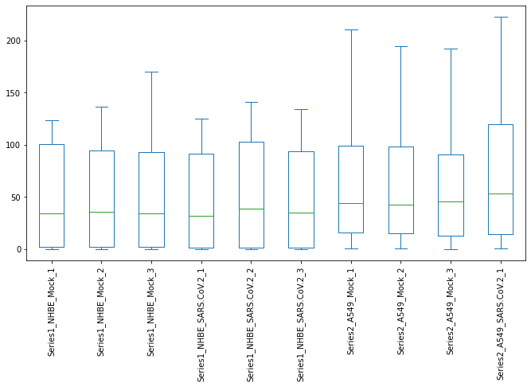

```python
df.iloc[:,:10].plot.box(figsize=(10, 5)); # plot boxplot of the first 4 columns #figsize=(width, height) is the size of the figure in inches #plt.show() to show the plot
plt.tight_layout() #tight layout to make the plot more compact and readable
plt.xticks(rotation=90) #rotate the x-axis labels 90 degrees clockwise
```